# Mcap Developmental pH Series of Symbiont Gene Expression in *M. capitata*

Erin Chille

Last updated 2020/11/12

# BSF Biomineralization Project: RNAseq Expression and Functional Analysis

## Set up workspace

Import necessary libraries

```r
library("tidyverse")
library("genefilter")
library("DESeq2")
library("RColorBrewer")
library("gridExtra")
library("ComplexHeatmap")
library("dplyr")
```

## Data input, cleaning, and pre-processing

Import the data files

```r
treatmentinfo <- read.csv("Sample_Info/RNAseq_data.csv", header = TRUE, sep = ",", row.names = "sample_id")
head(treatmentinfo)
```

```
##            time_point treatment extraction_batch
## X119 Unfertilized_egg       amb                0
## X120 Unfertilized_egg       amb                0
## X121 Unfertilized_egg       amb               12
## X127   Fertilized_egg       amb               10
## X128   Fertilized_egg         l               11
## X129   Fertilized_egg        xl               10
```

```r
gcount <- as.data.frame(read.csv("7-Symbiont-RNAseq-Analysis/a-QC-Align-Assemble/Output/sym_gene_count_matrix.csv", row.names="gene_id"), colClasses = double)
gcount <- gcount[ ,rownames(treatmentinfo)] #remove samples not in the treatment information csv (i.e. not in experiment)
dim(gcount)
```

```
## [1] 102507     44
```

```r
head(gcount)
```

```
##        X119 X120 X121 X127 X128 X129 X130 X131 X132 X133 X134 X153 X154 X155
## g16981    0    0   29    0   36    0    0   32    0    0   23    0    0    0
## g16980   12    0   10    0    0    0    0    0    0    0    0    0    0    0
## g16983    0    0    0    0    0    0    0    0    0    0    0    0    0    0
## g16982    0    0    0    0    0    0    0    0    0    0    0    0    0    0
## g16985    0    0    0    0    0    0    0    0    0    0   12    0    0    0
## g16984    0    0    0    0    0    0    0    0    0    0    0    0    0    0
##        X156 X157 X158 X159 X160 X162 X163 X164 X165 X166 X167 X168 X169 X179
## g16981    0   22    0   15    0    0    0    0    0    0    0    0    0    0
## g16980    0    0    0    0    0    0    0    0    0    0    0    0    0    0
## g16983    0    0    0   10    0    0    0    0    0    0    0    0    0    0
## g16982    0    0    0    0    0    0    0    0    0    0    0    0    0    0
## g16985    0    8    0    0    0    0    0    0    0    0    0    0    0    0
## g16984    0    0    0    0    0    0    0    0    0    0    0    0    0    0
##        X180 X181 X182 X183 X184 X185 X186 X359 X361 X363 X365 X367 X371 X373
## g16981    0    0    0    0    0    6    0    0    0    0    0    0    0    0
## g16980    0    0    0    0    0    0    0    0    0    0    0    0    0    0
## g16983    0    0    0    0    0    0    0    0    0    0    0    0    0    0
## g16982    0    0    0    0    0    0    0    0    0    0    0    0    0    0
## g16985    0    0    0    0    0    0    0    0    0    0    0    0    0    0
## g16984    0    0    0    0    0    0    0    0    0    0    0    0    0    0
##        X375 X379
## g16981    0    0
## g16980    0    0
## g16983    0    0
## g16982    0    0
## g16985    0    0
## g16984    0    0
```

#### Quality-filter gene counts

```r
#keep only life stages with samples from all pH treatments in treatmentinfo and count data
treatmentinfo_dev <- filter(treatmentinfo, time_point!="Unfertilized_egg")
dim(treatmentinfo_dev) #rows should be 24
```

```
## [1] 41  3
```

```r
# delete sample columns corresponding to low and extreme low samples by mapping Null value to them
gcount_dev <- gcount[rownames(treatmentinfo_dev)]
dim(gcount_dev) #columns should be 24
```

```
## [1] 102507     41
```

```r
#create filter for the counts data
#gfiltdev <- rowSums(count(gcount_dev)) > 0
#set filter values for PoverA, P=100% percent of the samples have counts over A=10. This means that only 2 out of 24 (0.083) samples need to have counts over 10. Our smallest sample size for our life stages is two (fertilized egg, mid-gastrula, early-gastrula). By setting 2/24 as the P, this means if a particular gene is expressed only in 1 of these smallest life stages, it will be included in the analysis.
filt <- filterfun(pOverA(0.083,10))

#create filter for the counts data
gfiltdev <- genefilter(gcount_dev, filt)

#identify genes to keep by count filter
gkeepdev <- gcount_dev[gfiltdev,]


#identify genes to keep by count filter
gkeepdev <- gcount_dev[gfiltdev,]

#identify gene lists
gn.keepdev <- rownames(gkeepdev)

#gene count data filtered in PoverA, P percent of the samples have counts over A
gcount_filt_dev <- as.data.frame(gcount_dev[which(rownames(gcount_dev) %in% gn.keepdev),])

#How many rows do we have before and after filtering?
nrow(gcount_dev) #Before
```

```
## [1] 102507
```

```r
nrow(gcount_filt_dev) #After
```

```
## [1] 13726
```

### Read normalization

We are now going normalize our read counts using VST-normalization in DESeq2

#### Construct the DESeq2 dataset

```r
treatmentinfo_dev$time_point <- factor(treatmentinfo_dev$time_point, levels = c("Fertilized_egg", "Cleavage", "Prawn_chip", "Early_gastrula", "Planula"))
treatmentinfo_dev$treatment <- factor(treatmentinfo_dev$treatment, levels = c("amb", "l", "xl"))
```

Create a DESeqDataSet design from gene count matrix and labels. Here we set the design to look at time_point to test for any differences in gene expression across timepoints.

```r
#Set DESeq2 design
gdds_dev <- DESeqDataSetFromMatrix(countData = gcount_filt_dev,
                              colData = treatmentinfo_dev,
                              design = ~time_point)
```

#### Log-transform the count data

First we are going to log-transform the data using a variance stabilizing transforamtion (VST). This is only for visualization purposes. Essentially, this is roughly similar to putting the data on the log2 scale. It will deal with the sampling variability of low counts by calculating within-group variability (if blind=FALSE). Importantly, it does not use the design to remove variation in the data, and so can be used to examine if there may be any variability do to technical factors such as extraction batch effects.

To do this we first need to calculate the size factors of our samples. This is a rough estimate of how many reads each sample contains compared to the others. In order to use VST (the faster log2 transforming process) to log-transform our data, the size factors need to be less than 4. Otherwise, there could be artefacts in our results.

```r
SF.gdds_dev <- estimateSizeFactors(gdds_dev) #estimate size factors to determine if we can use vst  to transform our data. Size factors should be less than four to use vst
print(sizeFactors(SF.gdds_dev)) #View size factors
```

```
##      X127      X128      X129      X130      X131      X132      X133      X134
## 6.8623633 4.7047921 4.1667004 0.4100787 6.2903907 6.6219506 1.2261127 6.0467080
##      X153      X154      X155      X156      X157      X158      X159      X160
## 0.5509171 0.7316463 0.5559860 1.3503538 6.0600229 0.9464077 3.8653617 1.3328645
##      X162      X163      X164      X165      X166      X167      X168      X169
## 1.6939900 0.9073913 0.5897393 0.8335814 1.2878322 1.7504656 2.2674489 0.2696276
##      X179      X180      X181      X182      X183      X184      X185      X186
## 1.6253148 3.6663364 1.0158145 0.8749316 0.6159875 3.1300147 1.5941709 2.0236840
##      X359      X361      X363      X365      X367      X371      X373      X375
## 0.2451557 0.1815130 0.5154149 0.1084049 0.2116551 0.1023519 0.2821031 0.3815889
##      X379
## 0.0769344
```

Our size factors are NOT all less than 4, so we can use RLOG!

```r
grlog_dev <- rlog(gdds_dev, blind=TRUE) #apply a variance stabilizing transforamtion to minimize effects of small counts and normalize wrt library size
```

```
## rlog() may take a few minutes with 30 or more samples,
## vst() is a much faster transformation
```

```r
head(assay(grlog_dev), 3) #view transformed gene count data
```

```
##                X127       X128       X129         X130       X131       X132
## g16981   -0.7326421  0.3620745 -0.7316108 -0.613403379  0.1277940 -0.7325839
## g16989   -0.1313889  0.8332236 -0.1278380 -0.001681786  0.8698322  0.5638850
## s327_g37  1.3420239 -0.3056282 -0.3044382 -0.140885433 -0.3079759  1.0006566
##                X133        X134       X153        X154        X155       X156
## g16981   -0.7255844 -0.01968411 -0.6593223 -0.70344915 -0.66074682 -0.7263449
## g16989   -0.1076934  1.51136618 -0.0778353 -0.09052655 -0.07828551 -0.1101813
## s327_g37 -0.2812858  0.93133784 -0.2284685 -0.26185806 -0.23118549 -0.2841238
##                X157       X158        X159       X160       X162       X163
## g16981   -0.0416842 -0.7231897 -0.01130254 -0.7262460 -0.7278895 -0.7227463
## g16989    0.2740471 -0.0999552  1.04391695 -0.1098569  1.2417806 -0.0985381
## s327_g37  1.4985226 -0.2724956  0.67181283 -0.2837534 -0.2899595 -0.2708917
##                 X164        X165       X166       X167       X168        X169
## g16981   -0.66991356 -0.72180247 -0.7259796 -0.7280874 -0.7294545 -0.54818704
## g16989   -0.08111633 -0.09553691 -0.1089845  0.9736877  1.6330515  0.12131096
## s327_g37 -0.24866957 -0.26750101 -0.2827578 -0.2907146 -0.2959744 -0.01649569
##                X179       X180       X181        X182        X183       X184
## g16981   -0.7276309 -0.7312556 -0.7238993 -0.72234947 -0.67668643 -0.7307514
## g16989   -0.1144229  0.7151097 -0.1022335 -0.09727365 -0.08313503 -0.1249027
## s327_g37  0.8547003  0.1228792 -0.2750779 -0.26946218 -0.25357293  0.9251461
##                 X185       X186       X359       X361        X363       X365
## g16981   -0.03055311 -0.7288942 -0.5333883 -0.4866403 -0.64896190 -0.4064698
## g16989    1.33868678  0.8167088  0.1492202  0.2373832 -0.06874228  0.3885782
## s327_g37 -0.28850399  1.4676867  1.4627942  0.1008949 -0.20870762  0.2538072
##                 X367       X371        X373        X375       X379
## g16981   -0.51053494 -0.3975335 -0.55522195 -0.60220414 -0.3531343
## g16989    0.19231978  0.4054314  0.10804369  0.01943908  0.4891646
## s327_g37  0.05531968  0.2708519 -0.02991365 -0.11952467  0.3555362
```

##### Plot a heatmap of sample-to-sample distances

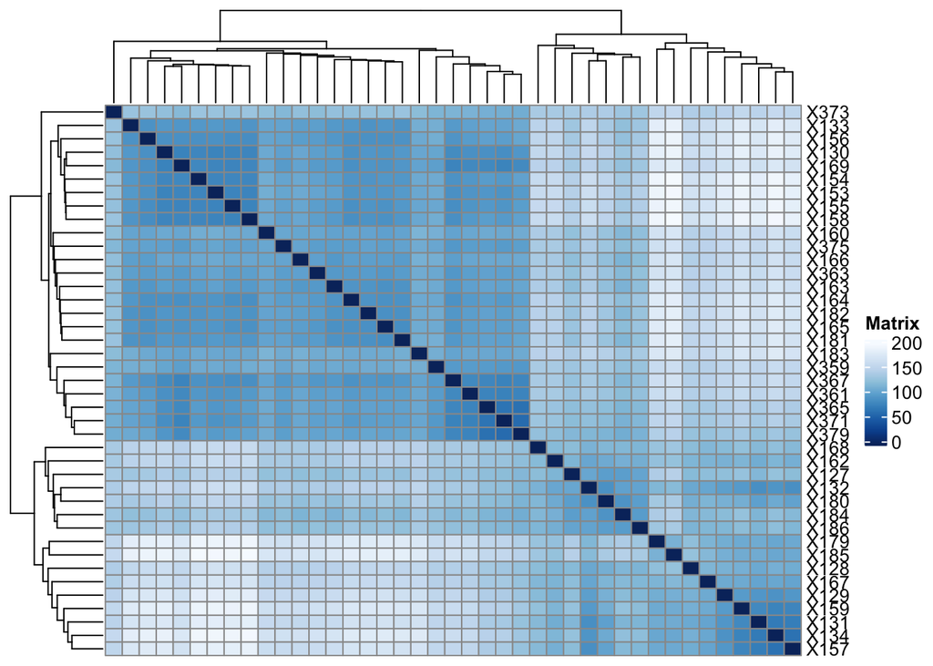

```r
gsampleDists_dev <- dist(t(assay(grlog_dev))) #calculate distance matix
gsampleDistMatrix_dev <- as.matrix(gsampleDists_dev) #distance matrix
rownames(gsampleDistMatrix_dev) <- colnames(grlog_dev) #assign row names
colnames(gsampleDistMatrix_dev) <- NULL #assign col names
colors <- colorRampPalette( rev(brewer.pal(9, "Blues")) )(255) #assign colors
pheatmap(gsampleDistMatrix_dev, #plot matrix
         clustering_distance_rows=gsampleDists_dev, #cluster rows
         clustering_distance_cols=gsampleDists_dev, #cluster columns
         col=colors) #set colors
```

##### Principal component plot of samples

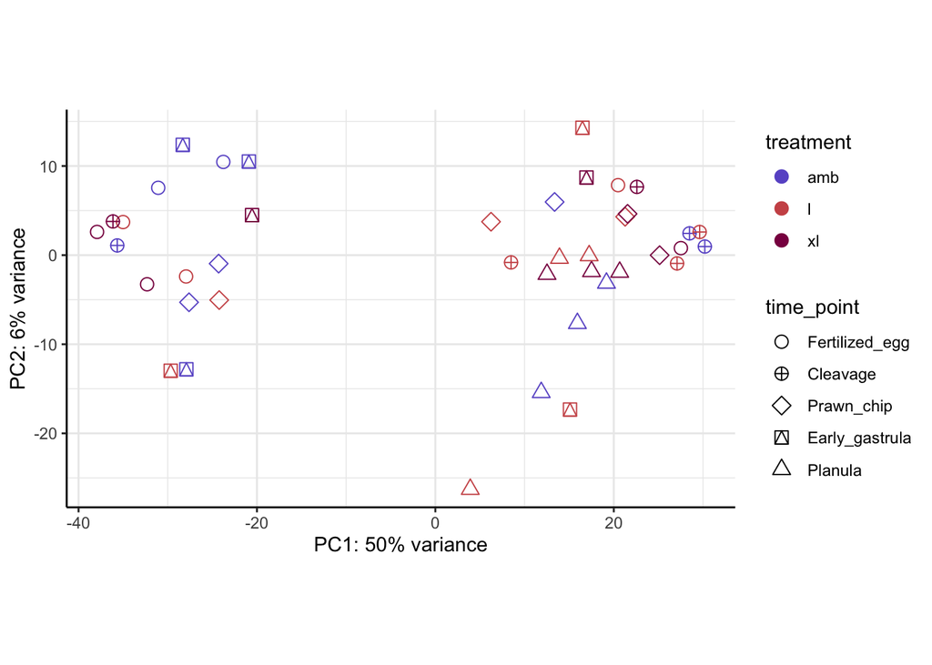

```r
gPCAdata_dev <- plotPCA(grlog_dev, intgroup = c("time_point"), returnData=TRUE)
percentVar_dev <- round(100*attr(gPCAdata_dev, "percentVar")) #plot PCA of samples with all data
treatmentinfo_dev$name <- rownames(treatmentinfo_dev)
gPCAdata_dev <- merge(gPCAdata_dev, treatmentinfo_dev[,c(2,4)], by = "name")
gPCAdata_dev <- plotPCA(grlog_dev, intgroup = c("time_point", "treatment"), returnData=TRUE)
percentVar_dev <- round(100*attr(gPCAdata_dev, "percentVar")) #plot PCA of samples with all data

allgenesfilt_PCA <- ggplot(gPCAdata_dev, aes(PC1, PC2, shape=time_point, color=treatment)) +
  geom_point(size=3) +
  xlab(paste0("PC1: ",percentVar_dev[1],"% variance")) +
  ylab(paste0("PC2: ",percentVar_dev[2],"% variance")) +
  scale_shape_manual(values = c("Fertilized_egg"=1, "Cleavage"=10, "Prawn_chip"=5, "Early_gastrula"=14, "Planula"=2)) +
  scale_color_manual(values = c("amb"="slateblue", "l"="indianred3", "xl"="deeppink4")) +
  coord_fixed() +
    theme_bw() + #Set background color
  theme(panel.border = element_blank(), # Set border
                     #panel.grid.major = element_blank(), #Set major gridlines
                     #panel.grid.minor = element_blank(), #Set minor gridlines
                     axis.line = element_line(colour = "black"), #Set axes color
        plot.background=element_blank()) # + #Set the plot background
  #theme(legend.position = ("none")) #set title attributes
allgenesfilt_PCA
```